# EU-ForDAM: damage graphs

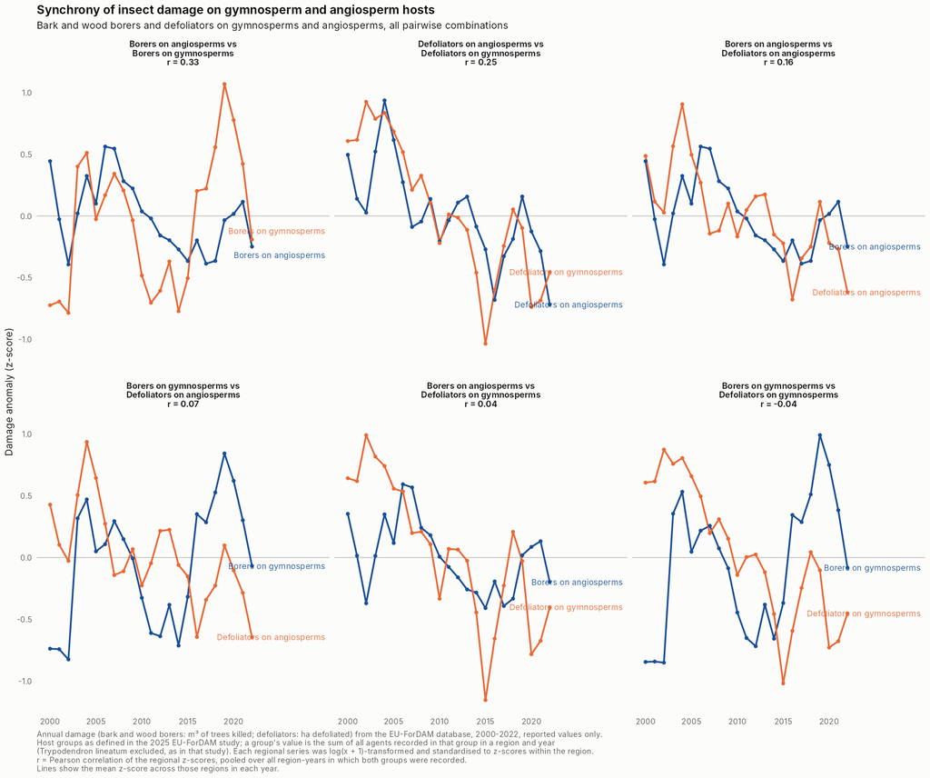

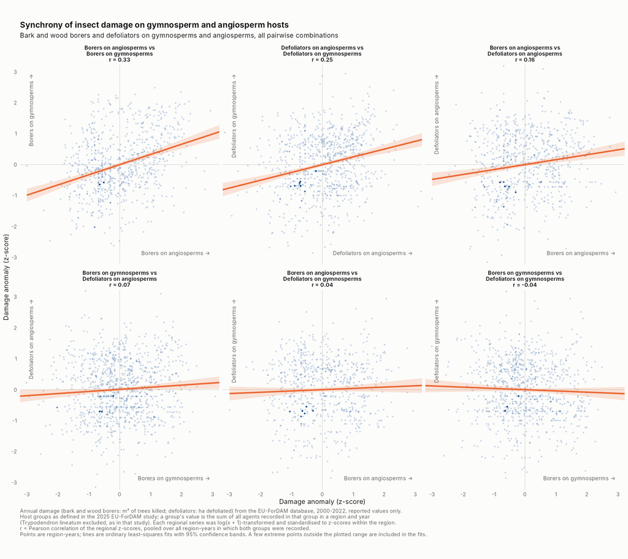

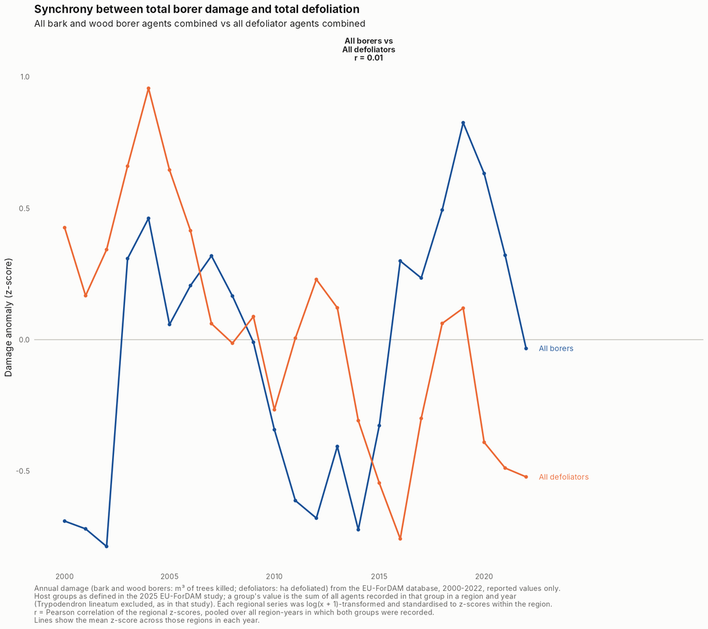

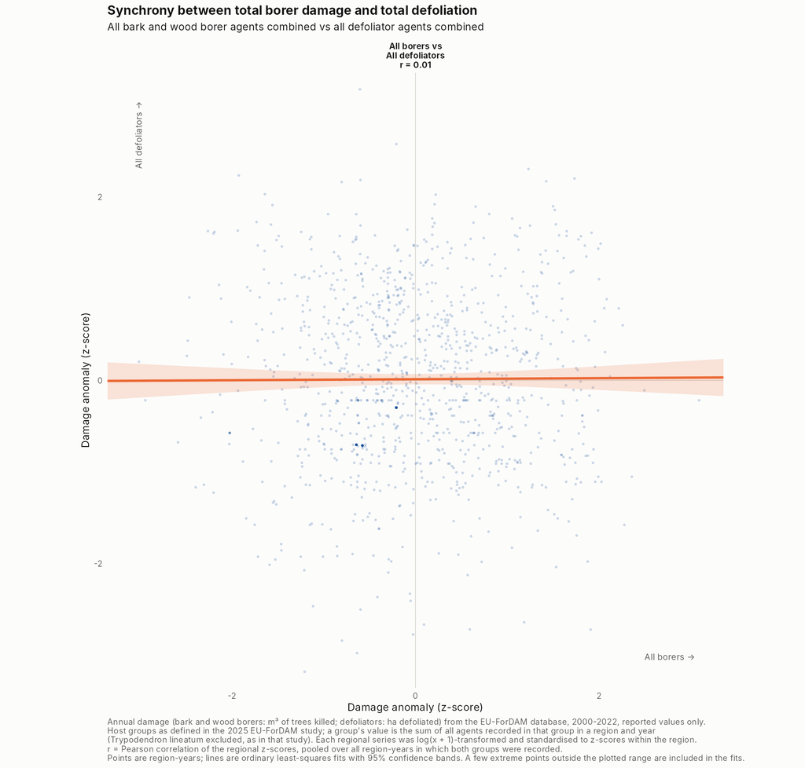

## 6. Bringing in more countries

Species pairs can only be tested where both insects are reported, mostly Germany, Czechia, Poland and Lithuania (Finland, Sweden and Switzerland report only *I. typographus*). Two ways to use more countries:

**(1) The paper’s groups.** Group value = sum of all member codes in a region-year (aggregates included), so countries reporting few insects still contribute. Correlation per country and pooled.

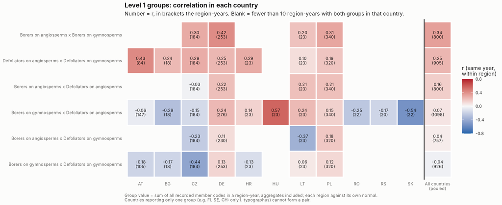

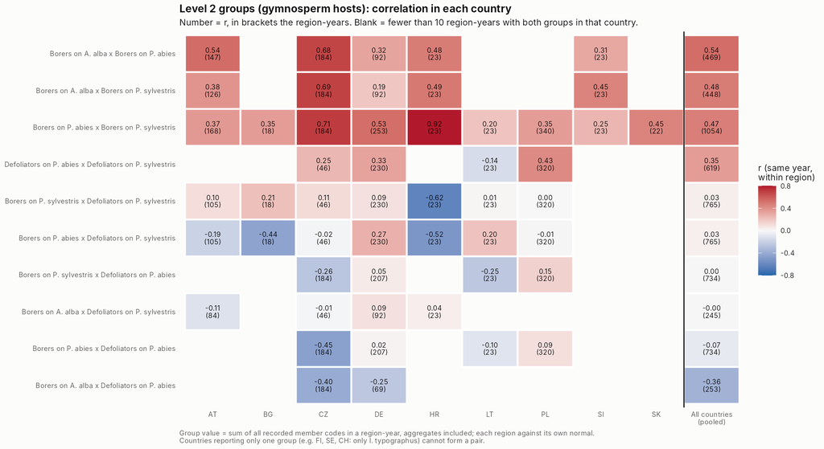

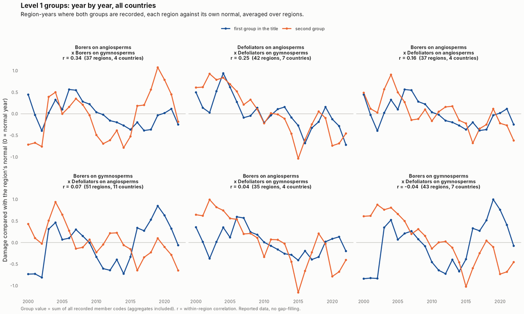

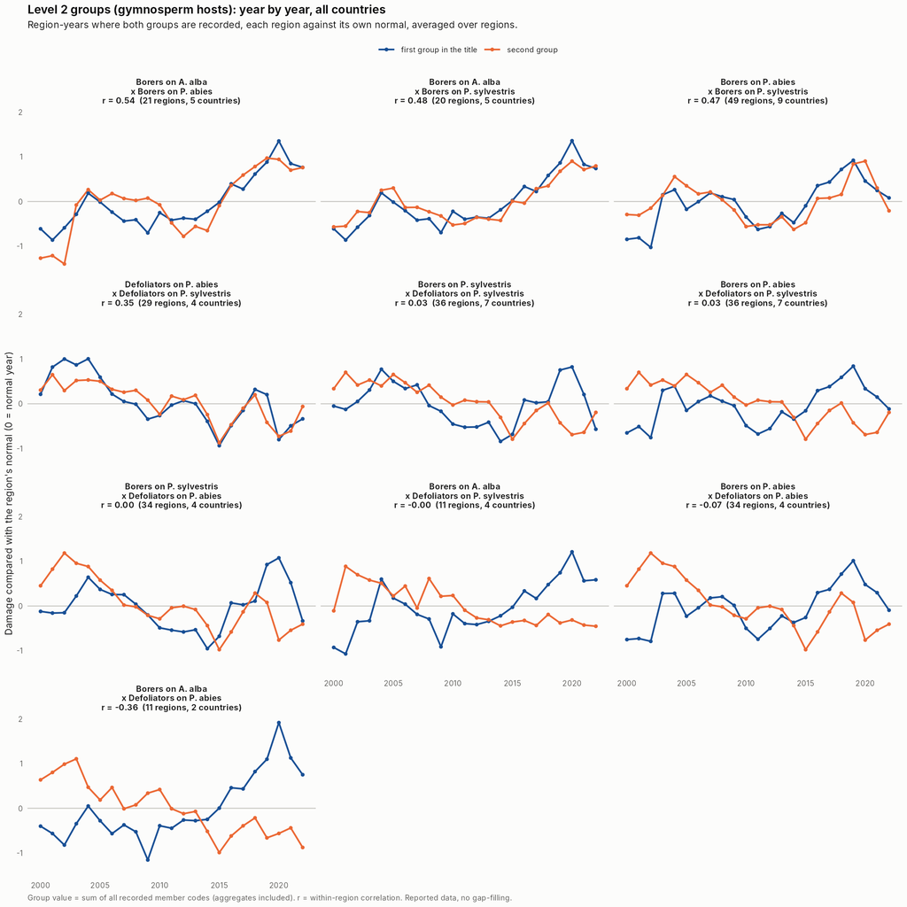

**(2) Europe-wide yearly totals (the 2025 paper’s approach).** For each insect or group, the sum over every reporting region of every country each year, log(1 + x), correlated over the 23 years.

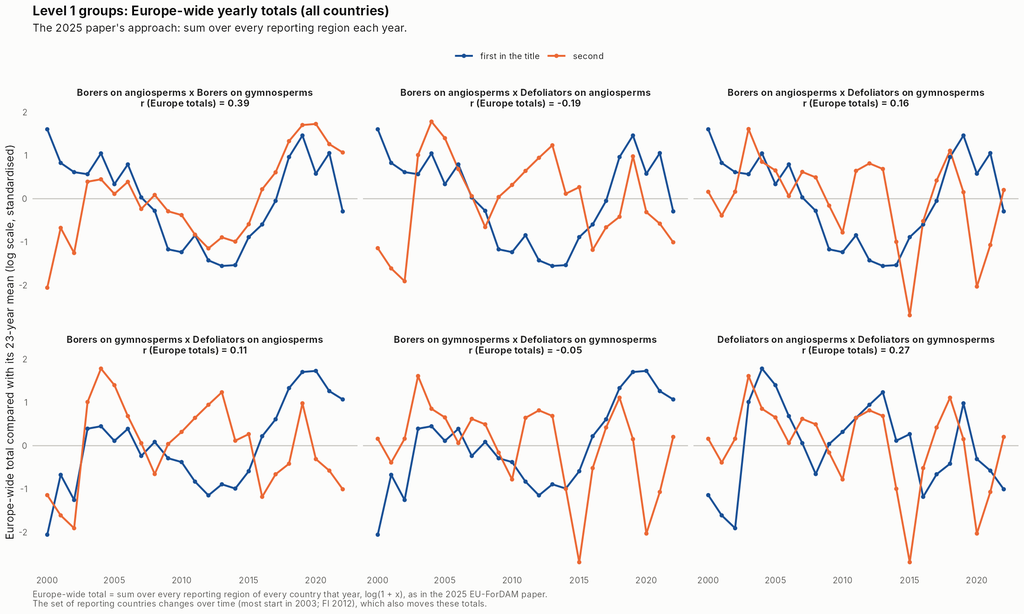

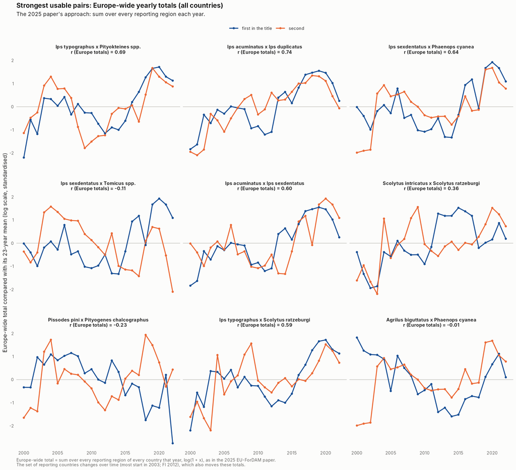

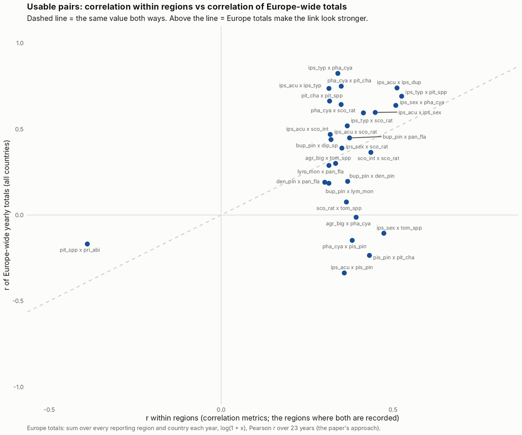

## Things to keep in mind

- Germany carries 52% of all borer damage and Poland 50% of all defoliation; most countries start reporting in 2003 (Austria 2002, Poland 2003, Finland 2012).
- Some dips come from how values were recorded, not from the insects: Bavaria *I. typographus* 2007 (6,000 m³) and 2009 (3,633 m³) next to millions in other years, and 0 in 2015; Hesse and Saxony-Anhalt report 0 for every insect from 2006–2007 on. These are listed in `outputs/tables/CHECK_suspicious_values_for_data_providers.csv`.
- Defoliated hectares are hectare-years: the same stand can count in several years and under several species.
- Averages hide outbreaks: e.g. *L. dispar* averages about 105,000 ha a year but a typical year is about 29,000 ha.
- In the defoliator guild share graphs *Melolontha* is left out (it feeds in all forest, not only broadleaves); it is included in the total-damage graphs.
- Bulgaria and Lithuania single-species growing stocks in the forest appendix are read as 1,000 m³ (otherwise far below their reported damage).

## 7. Summary of the usable pairs (with the multiple-testing check)

786 pairs could be measured. Testing that many, about 39 would look “sure” by luck alone. The false discovery rate (FDR, Benjamini-Hochberg) correction allows for this: after it, 150 links stay sure, and **all 28 usable pairs stay sure** (q < 0.05). p-values come from the same region bootstrap as the 95% ranges (whole regions resampled, 9,999 draws).

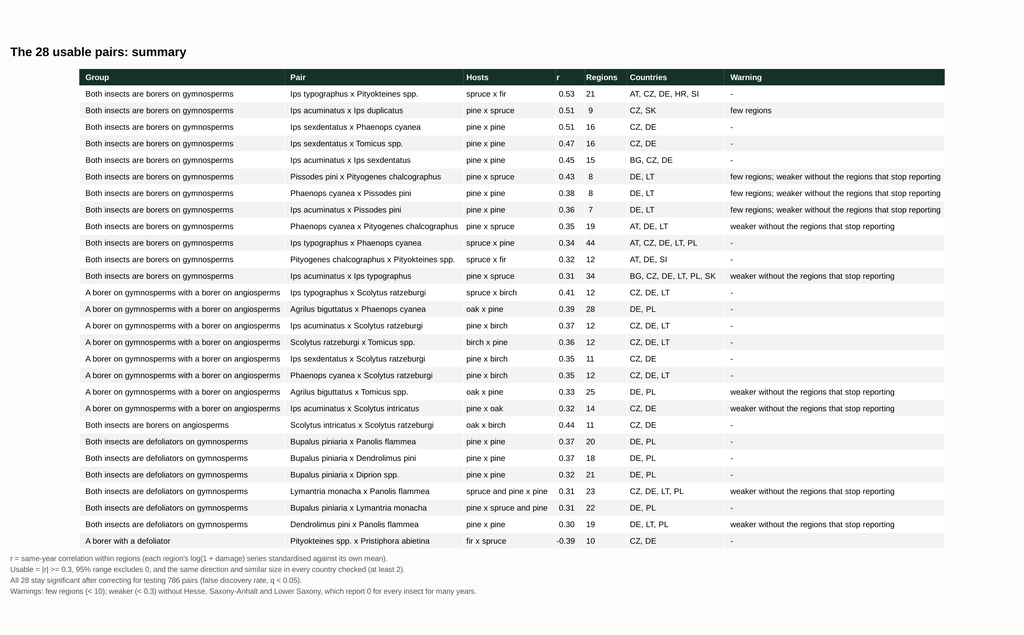

Two further checks are in `outputs/tables/CM_usable_pairs_robustness.csv`. In the time-shift test, one insect’s years are moved round inside each region; all 28 pairs stay well above what trends alone give. In the leave-one-country-out test, no pair changes sign.

Table: `outputs/tables/CM_usable_pairs_summary.csv`; every pair with p and q: `outputs/tables/CM_pairs_fdr.csv`.